# Risk Factor Analysis

## Outcome Variable

**Outcome Variable:** pers_wast

## Predictor Variables

**Intervention Variable:** mwtkg

**Adjustment Set:**

- arm
- W_mage
- meducyrs
- feducyrs
- single
- brthmon
- W_parity
- delta_W_mage
- delta_meducyrs
- delta_feducyrs
- delta_single
- delta_brthmon
- delta_W_parity

## Stratifying Variables

The analysis was stratified on these variable(s):

- agecat
- studyid
- country

## Data Summary

| agecat | studyid | country | mwtkg | pers_wast | n_cell | n |
| --- | --- | --- | --- | --- | --- | --- |
| 0-24 months | iLiNS-Zinc | BURKINA FASO | >=58 kg | 0 | 455 | 1645 |
| 0-24 months | iLiNS-Zinc | BURKINA FASO | >=58 kg | 1 | 32 | 1645 |
| 0-24 months | iLiNS-Zinc | BURKINA FASO | <52 kg | 0 | 514 | 1645 |
| 0-24 months | iLiNS-Zinc | BURKINA FASO | <52 kg | 1 | 102 | 1645 |
| 0-24 months | iLiNS-Zinc | BURKINA FASO | [52-58) kg | 0 | 483 | 1645 |
| 0-24 months | iLiNS-Zinc | BURKINA FASO | [52-58) kg | 1 | 59 | 1645 |
| 0-24 months | JiVitA-3 | BANGLADESH | >=58 kg | 0 | 372 | 15795 |
| 0-24 months | JiVitA-3 | BANGLADESH | >=58 kg | 1 | 17 | 15795 |
| 0-24 months | JiVitA-3 | BANGLADESH | <52 kg | 0 | 13489 | 15795 |
| 0-24 months | JiVitA-3 | BANGLADESH | <52 kg | 1 | 827 | 15795 |
| 0-24 months | JiVitA-3 | BANGLADESH | [52-58) kg | 0 | 1037 | 15795 |
| 0-24 months | JiVitA-3 | BANGLADESH | [52-58) kg | 1 | 53 | 15795 |
| 0-24 months | LCNI-5 | MALAWI | >=58 kg | 0 | 96 | 717 |
| 0-24 months | LCNI-5 | MALAWI | >=58 kg | 1 | 1 | 717 |
| 0-24 months | LCNI-5 | MALAWI | <52 kg | 0 | 426 | 717 |
| 0-24 months | LCNI-5 | MALAWI | <52 kg | 1 | 3 | 717 |
| 0-24 months | LCNI-5 | MALAWI | [52-58) kg | 0 | 189 | 717 |
| 0-24 months | LCNI-5 | MALAWI | [52-58) kg | 1 | 2 | 717 |
| 0-24 months | MAL-ED | BANGLADESH | >=58 kg | 0 | 45 | 248 |
| 0-24 months | MAL-ED | BANGLADESH | >=58 kg | 1 | 2 | 248 |
| 0-24 months | MAL-ED | BANGLADESH | <52 kg | 0 | 149 | 248 |
| 0-24 months | MAL-ED | BANGLADESH | <52 kg | 1 | 9 | 248 |
| 0-24 months | MAL-ED | BANGLADESH | [52-58) kg | 0 | 41 | 248 |
| 0-24 months | MAL-ED | BANGLADESH | [52-58) kg | 1 | 2 | 248 |
| 0-24 months | MAL-ED | BRAZIL | >=58 kg | 0 | 139 | 216 |
| 0-24 months | MAL-ED | BRAZIL | >=58 kg | 1 | 1 | 216 |
| 0-24 months | MAL-ED | BRAZIL | <52 kg | 0 | 40 | 216 |
| 0-24 months | MAL-ED | BRAZIL | <52 kg | 1 | 0 | 216 |
| 0-24 months | MAL-ED | BRAZIL | [52-58) kg | 0 | 35 | 216 |
| 0-24 months | MAL-ED | BRAZIL | [52-58) kg | 1 | 1 | 216 |

[output cut: 258 more lines]

The following strata were considered:

- agecat: 0-24 months, studyid: iLiNS-Zinc, country: BURKINA FASO
- agecat: 0-24 months, studyid: JiVitA-3, country: BANGLADESH
- agecat: 0-24 months, studyid: LCNI-5, country: MALAWI
- agecat: 0-24 months, studyid: MAL-ED, country: BANGLADESH
- agecat: 0-24 months, studyid: MAL-ED, country: BRAZIL
- agecat: 0-24 months, studyid: MAL-ED, country: INDIA
- agecat: 0-24 months, studyid: MAL-ED, country: NEPAL
- agecat: 0-24 months, studyid: MAL-ED, country: PERU
- agecat: 0-24 months, studyid: MAL-ED, country: SOUTH AFRICA
- agecat: 0-24 months, studyid: MAL-ED, country: TANZANIA, UNITED REPUBLIC OF
- agecat: 0-24 months, studyid: NIH-Birth, country: BANGLADESH
- agecat: 0-24 months, studyid: NIH-Crypto, country: BANGLADESH
- agecat: 0-24 months, studyid: PROBIT, country: BELARUS
- agecat: 0-24 months, studyid: PROVIDE, country: BANGLADESH
- agecat: 0-24 months, studyid: SAS-CompFeed, country: INDIA
- agecat: 0-24 months, studyid: TanzaniaChild2, country: TANZANIA, UNITED REPUBLIC OF
- agecat: 0-24 months, studyid: ZVITAMBO, country: ZIMBABWE
- agecat: 0-6 months, studyid: JiVitA-3, country: BANGLADESH
- agecat: 0-6 months, studyid: MAL-ED, country: BANGLADESH
- agecat: 0-6 months, studyid: MAL-ED, country: BRAZIL
- agecat: 0-6 months, studyid: MAL-ED, country: INDIA
- agecat: 0-6 months, studyid: MAL-ED, country: NEPAL
- agecat: 0-6 months, studyid: MAL-ED, country: PERU
- agecat: 0-6 months, studyid: MAL-ED, country: SOUTH AFRICA
- agecat: 0-6 months, studyid: MAL-ED, country: TANZANIA, UNITED REPUBLIC OF
- agecat: 0-6 months, studyid: NIH-Birth, country: BANGLADESH
- agecat: 0-6 months, studyid: NIH-Crypto, country: BANGLADESH
- agecat: 0-6 months, studyid: PROBIT, country: BELARUS
- agecat: 0-6 months, studyid: PROVIDE, country: BANGLADESH
- agecat: 0-6 months, studyid: TanzaniaChild2, country: TANZANIA, UNITED REPUBLIC OF
- agecat: 0-6 months, studyid: ZVITAMBO, country: ZIMBABWE
- agecat: 6-24 months, studyid: iLiNS-Zinc, country: BURKINA FASO
- agecat: 6-24 months, studyid: JiVitA-3, country: BANGLADESH
- agecat: 6-24 months, studyid: LCNI-5, country: MALAWI
- agecat: 6-24 months, studyid: MAL-ED, country: BANGLADESH
- agecat: 6-24 months, studyid: MAL-ED, country: BRAZIL
- agecat: 6-24 months, studyid: MAL-ED, country: INDIA
- agecat: 6-24 months, studyid: MAL-ED, country: NEPAL
- agecat: 6-24 months, studyid: MAL-ED, country: PERU
- agecat: 6-24 months, studyid: MAL-ED, country: SOUTH AFRICA
- agecat: 6-24 months, studyid: MAL-ED, country: TANZANIA, UNITED REPUBLIC OF
- agecat: 6-24 months, studyid: NIH-Birth, country: BANGLADESH
- agecat: 6-24 months, studyid: NIH-Crypto, country: BANGLADESH
- agecat: 6-24 months, studyid: PROBIT, country: BELARUS
- agecat: 6-24 months, studyid: PROVIDE, country: BANGLADESH
- agecat: 6-24 months, studyid: SAS-CompFeed, country: INDIA
- agecat: 6-24 months, studyid: TanzaniaChild2, country: TANZANIA, UNITED REPUBLIC OF
- agecat: 6-24 months, studyid: ZVITAMBO, country: ZIMBABWE

### Dropped Strata

Some strata were dropped due to rare outcomes:

- agecat: 0-24 months, studyid: LCNI-5, country: MALAWI
- agecat: 0-24 months, studyid: MAL-ED, country: BANGLADESH
- agecat: 0-24 months, studyid: MAL-ED, country: BRAZIL
- agecat: 0-24 months, studyid: MAL-ED, country: INDIA
- agecat: 0-24 months, studyid: MAL-ED, country: NEPAL
- agecat: 0-24 months, studyid: MAL-ED, country: PERU
- agecat: 0-24 months, studyid: MAL-ED, country: SOUTH AFRICA
- agecat: 0-24 months, studyid: MAL-ED, country: TANZANIA, UNITED REPUBLIC OF
- agecat: 0-24 months, studyid: NIH-Birth, country: BANGLADESH
- agecat: 0-24 months, studyid: NIH-Crypto, country: BANGLADESH
- agecat: 0-24 months, studyid: PROBIT, country: BELARUS
- agecat: 0-24 months, studyid: PROVIDE, country: BANGLADESH
- agecat: 0-24 months, studyid: SAS-CompFeed, country: INDIA
- agecat: 0-6 months, studyid: JiVitA-3, country: BANGLADESH
- agecat: 0-6 months, studyid: MAL-ED, country: BANGLADESH
- agecat: 0-6 months, studyid: MAL-ED, country: BRAZIL
- agecat: 0-6 months, studyid: MAL-ED, country: INDIA
- agecat: 0-6 months, studyid: MAL-ED, country: NEPAL
- agecat: 0-6 months, studyid: MAL-ED, country: PERU
- agecat: 0-6 months, studyid: MAL-ED, country: SOUTH AFRICA
- agecat: 0-6 months, studyid: MAL-ED, country: TANZANIA, UNITED REPUBLIC OF
- agecat: 0-6 months, studyid: NIH-Birth, country: BANGLADESH
- agecat: 0-6 months, studyid: NIH-Crypto, country: BANGLADESH
- agecat: 0-6 months, studyid: PROVIDE, country: BANGLADESH
- agecat: 0-6 months, studyid: ZVITAMBO, country: ZIMBABWE
- agecat: 6-24 months, studyid: LCNI-5, country: MALAWI
- agecat: 6-24 months, studyid: MAL-ED, country: BANGLADESH
- agecat: 6-24 months, studyid: MAL-ED, country: BRAZIL
- agecat: 6-24 months, studyid: MAL-ED, country: INDIA
- agecat: 6-24 months, studyid: MAL-ED, country: NEPAL
- agecat: 6-24 months, studyid: MAL-ED, country: PERU
- agecat: 6-24 months, studyid: MAL-ED, country: SOUTH AFRICA
- agecat: 6-24 months, studyid: MAL-ED, country: TANZANIA, UNITED REPUBLIC OF
- agecat: 6-24 months, studyid: NIH-Birth, country: BANGLADESH
- agecat: 6-24 months, studyid: NIH-Crypto, country: BANGLADESH
- agecat: 6-24 months, studyid: PROBIT, country: BELARUS
- agecat: 6-24 months, studyid: PROVIDE, country: BANGLADESH
- agecat: 6-24 months, studyid: SAS-CompFeed, country: INDIA

## Methods Detail

We’re interested in the causal parameters $E[Y_a]$ for all values of $a \in \mathcal{A}$. These parameters represent the mean outcome if, possibly contrary to fact, we intervened to set all units to have $A=a$. Under the randomization and positivity assumptions, these are identified by the statistical parameters $\psi_a=E_W[E_{Y|A,W}(Y|A=a,W)]$. In addition, we’re interested in the mean of $Y$, $E[Y]$ under no intervention (the observed mean). We will estimate these parameters by using SuperLearner to fit the relevant likelihood factors – $E_{Y|A,W}(Y|A=a,W)$ and $p(A=a|W)$, and then updating our likelihood fit using a joint TMLE.

For unadjusted analyses ($W=\{\}$), initial likelihoods were estimated using Lrnr_glm to estimate the simple $E(Y|A)$ and Lrnr_mean to estimate $p(A)$. For adjusted analyses, a small library containing Lrnr_glmnet, Lrnr_xgboost, and Lrnr_mean was used.

Having estimated these parameters, we will then use the delta method to estimate relative risks and attributable risks relative to a prespecified baseline level of $A$.

# Results Detail

## Results Plots

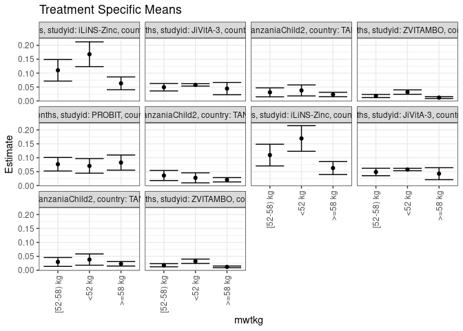

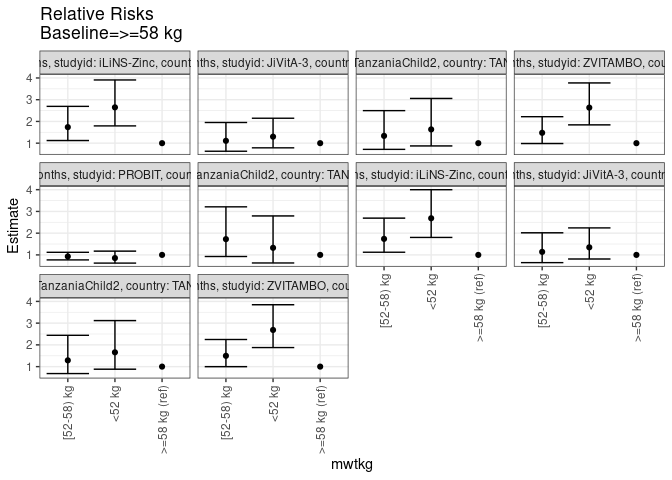

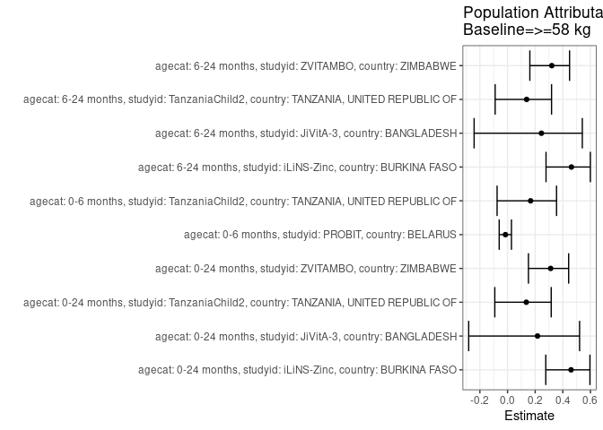

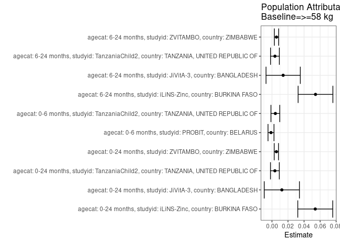

## Results Table

### Parameter: TSM

| agecat | studyid | country | intervention_level | baseline_level | estimate | ci_lower | ci_upper |
| --- | --- | --- | --- | --- | --- | --- | --- |
| 0-24 months | iLiNS-Zinc | BURKINA FASO | >=58 kg | NA | 0.0633793 | 0.0404214 | 0.0863372 |
| 0-24 months | iLiNS-Zinc | BURKINA FASO | <52 kg | NA | 0.1678256 | 0.1233287 | 0.2123225 |
| 0-24 months | iLiNS-Zinc | BURKINA FASO | [52-58) kg | NA | 0.1101553 | 0.0714824 | 0.1488281 |
| 0-24 months | JiVitA-3 | BANGLADESH | >=58 kg | NA | 0.0444684 | 0.0223748 | 0.0665619 |
| 0-24 months | JiVitA-3 | BANGLADESH | <52 kg | NA | 0.0577951 | 0.0535042 | 0.0620859 |
| 0-24 months | JiVitA-3 | BANGLADESH | [52-58) kg | NA | 0.0493130 | 0.0359331 | 0.0626929 |
| 0-24 months | TanzaniaChild2 | TANZANIA, UNITED REPUBLIC OF | >=58 kg | NA | 0.0231700 | 0.0151255 | 0.0312144 |
| 0-24 months | TanzaniaChild2 | TANZANIA, UNITED REPUBLIC OF | <52 kg | NA | 0.0378490 | 0.0181229 | 0.0575752 |
| 0-24 months | TanzaniaChild2 | TANZANIA, UNITED REPUBLIC OF | [52-58) kg | NA | 0.0309542 | 0.0148373 | 0.0470710 |
| 0-24 months | ZVITAMBO | ZIMBABWE | >=58 kg | NA | 0.0121082 | 0.0089562 | 0.0152602 |
| 0-24 months | ZVITAMBO | ZIMBABWE | <52 kg | NA | 0.0319181 | 0.0240680 | 0.0397682 |
| 0-24 months | ZVITAMBO | ZIMBABWE | [52-58) kg | NA | 0.0178862 | 0.0123111 | 0.0234614 |
| 0-6 months | PROBIT | BELARUS | >=58 kg | NA | 0.0826987 | 0.0555343 | 0.1098630 |
| 0-6 months | PROBIT | BELARUS | <52 kg | NA | 0.0707499 | 0.0444902 | 0.0970097 |
| 0-6 months | PROBIT | BELARUS | [52-58) kg | NA | 0.0767527 | 0.0524249 | 0.1010806 |
| 0-6 months | TanzaniaChild2 | TANZANIA, UNITED REPUBLIC OF | >=58 kg | NA | 0.0210117 | 0.0131679 | 0.0288554 |
| 0-6 months | TanzaniaChild2 | TANZANIA, UNITED REPUBLIC OF | <52 kg | NA | 0.0278638 | 0.0099107 | 0.0458168 |
| 0-6 months | TanzaniaChild2 | TANZANIA, UNITED REPUBLIC OF | [52-58) kg | NA | 0.0362319 | 0.0182271 | 0.0542366 |
| 6-24 months | iLiNS-Zinc | BURKINA FASO | >=58 kg | NA | 0.0630660 | 0.0398442 | 0.0862878 |
| 6-24 months | iLiNS-Zinc | BURKINA FASO | <52 kg | NA | 0.1693258 | 0.1232887 | 0.2153628 |
| 6-24 months | iLiNS-Zinc | BURKINA FASO | [52-58) kg | NA | 0.1095832 | 0.0706177 | 0.1485487 |
| 6-24 months | JiVitA-3 | BANGLADESH | >=58 kg | NA | 0.0428618 | 0.0213200 | 0.0644035 |
| 6-24 months | JiVitA-3 | BANGLADESH | <52 kg | NA | 0.0577934 | 0.0535016 | 0.0620851 |
| 6-24 months | JiVitA-3 | BANGLADESH | [52-58) kg | NA | 0.0488410 | 0.0355329 | 0.0621491 |
| 6-24 months | TanzaniaChild2 | TANZANIA, UNITED REPUBLIC OF | >=58 kg | NA | 0.0231022 | 0.0150623 | 0.0311420 |
| 6-24 months | TanzaniaChild2 | TANZANIA, UNITED REPUBLIC OF | <52 kg | NA | 0.0382899 | 0.0181157 | 0.0584640 |
| 6-24 months | TanzaniaChild2 | TANZANIA, UNITED REPUBLIC OF | [52-58) kg | NA | 0.0297717 | 0.0138336 | 0.0457099 |
| 6-24 months | ZVITAMBO | ZIMBABWE | >=58 kg | NA | 0.0119645 | 0.0088488 | 0.0150802 |
| 6-24 months | ZVITAMBO | ZIMBABWE | <52 kg | NA | 0.0321360 | 0.0241838 | 0.0400881 |
| 6-24 months | ZVITAMBO | ZIMBABWE | [52-58) kg | NA | 0.0179093 | 0.0123272 | 0.0234915 |

### Parameter: E(Y)

| agecat | studyid | country | intervention_level | baseline_level | estimate | ci_lower | ci_upper |
| --- | --- | --- | --- | --- | --- | --- | --- |
| 0-24 months | iLiNS-Zinc | BURKINA FASO | NA | NA | 0.1173252 | 0.0921861 | 0.1424644 |
| 0-24 months | JiVitA-3 | BANGLADESH | NA | NA | 0.0567901 | 0.0526750 | 0.0609052 |
| 0-24 months | TanzaniaChild2 | TANZANIA, UNITED REPUBLIC OF | NA | NA | 0.0268109 | 0.0199430 | 0.0336788 |
| 0-24 months | ZVITAMBO | ZIMBABWE | NA | NA | 0.0176014 | 0.0149065 | 0.0202963 |
| 0-6 months | PROBIT | BELARUS | NA | NA | 0.0814764 | 0.0558603 | 0.1070926 |
| 0-6 months | TanzaniaChild2 | TANZANIA, UNITED REPUBLIC OF | NA | NA | 0.0252226 | 0.0183864 | 0.0320587 |
| 6-24 months | iLiNS-Zinc | BURKINA FASO | NA | NA | 0.1173252 | 0.0921861 | 0.1424644 |
| 6-24 months | JiVitA-3 | BANGLADESH | NA | NA | 0.0567901 | 0.0526750 | 0.0609052 |
| 6-24 months | TanzaniaChild2 | TANZANIA, UNITED REPUBLIC OF | NA | NA | 0.0268109 | 0.0199430 | 0.0336788 |
| 6-24 months | ZVITAMBO | ZIMBABWE | NA | NA | 0.0176014 | 0.0149065 | 0.0202963 |

### Parameter: RR

| agecat | studyid | country | intervention_level | baseline_level | estimate | ci_lower | ci_upper |
| --- | --- | --- | --- | --- | --- | --- | --- |
| 0-24 months | iLiNS-Zinc | BURKINA FASO | >=58 kg | >=58 kg | 1.0000000 | 1.0000000 | 1.000000 |
| 0-24 months | iLiNS-Zinc | BURKINA FASO | <52 kg | >=58 kg | 2.6479566 | 1.7941151 | 3.908152 |
| 0-24 months | iLiNS-Zinc | BURKINA FASO | [52-58) kg | >=58 kg | 1.7380328 | 1.1215572 | 2.693360 |
| 0-24 months | JiVitA-3 | BANGLADESH | >=58 kg | >=58 kg | 1.0000000 | 1.0000000 | 1.000000 |
| 0-24 months | JiVitA-3 | BANGLADESH | <52 kg | >=58 kg | 1.2996896 | 0.7862392 | 2.148447 |
| 0-24 months | JiVitA-3 | BANGLADESH | [52-58) kg | >=58 kg | 1.1089461 | 0.6302207 | 1.951319 |
| 0-24 months | TanzaniaChild2 | TANZANIA, UNITED REPUBLIC OF | >=58 kg | >=58 kg | 1.0000000 | 1.0000000 | 1.000000 |
| 0-24 months | TanzaniaChild2 | TANZANIA, UNITED REPUBLIC OF | <52 kg | >=58 kg | 1.6335380 | 0.8730320 | 3.056527 |
| 0-24 months | TanzaniaChild2 | TANZANIA, UNITED REPUBLIC OF | [52-58) kg | >=58 kg | 1.3359614 | 0.7146259 | 2.497521 |
| 0-24 months | ZVITAMBO | ZIMBABWE | >=58 kg | >=58 kg | 1.0000000 | 1.0000000 | 1.000000 |
| 0-24 months | ZVITAMBO | ZIMBABWE | <52 kg | >=58 kg | 2.6360686 | 1.8425315 | 3.771364 |
| 0-24 months | ZVITAMBO | ZIMBABWE | [52-58) kg | >=58 kg | 1.4771982 | 0.9841046 | 2.217360 |
| 0-6 months | PROBIT | BELARUS | >=58 kg | >=58 kg | 1.0000000 | 1.0000000 | 1.000000 |
| 0-6 months | PROBIT | BELARUS | <52 kg | >=58 kg | 0.8555146 | 0.6236578 | 1.173569 |
| 0-6 months | PROBIT | BELARUS | [52-58) kg | >=58 kg | 0.9281010 | 0.7695672 | 1.119293 |
| 0-6 months | TanzaniaChild2 | TANZANIA, UNITED REPUBLIC OF | >=58 kg | >=58 kg | 1.0000000 | 1.0000000 | 1.000000 |
| 0-6 months | TanzaniaChild2 | TANZANIA, UNITED REPUBLIC OF | <52 kg | >=58 kg | 1.3261094 | 0.6297729 | 2.792381 |
| 0-6 months | TanzaniaChild2 | TANZANIA, UNITED REPUBLIC OF | [52-58) kg | >=58 kg | 1.7243693 | 0.9261992 | 3.210378 |
| 6-24 months | iLiNS-Zinc | BURKINA FASO | >=58 kg | >=58 kg | 1.0000000 | 1.0000000 | 1.000000 |
| 6-24 months | iLiNS-Zinc | BURKINA FASO | <52 kg | >=58 kg | 2.6848989 | 1.8025905 | 3.999068 |
| 6-24 months | iLiNS-Zinc | BURKINA FASO | [52-58) kg | >=58 kg | 1.7375964 | 1.1218217 | 2.691373 |
| 6-24 months | JiVitA-3 | BANGLADESH | >=58 kg | >=58 kg | 1.0000000 | 1.0000000 | 1.000000 |
| 6-24 months | JiVitA-3 | BANGLADESH | <52 kg | >=58 kg | 1.3483662 | 0.8110820 | 2.241563 |
| 6-24 months | JiVitA-3 | BANGLADESH | [52-58) kg | >=58 kg | 1.1394993 | 0.6439524 | 2.016389 |
| 6-24 months | TanzaniaChild2 | TANZANIA, UNITED REPUBLIC OF | >=58 kg | >=58 kg | 1.0000000 | 1.0000000 | 1.000000 |
| 6-24 months | TanzaniaChild2 | TANZANIA, UNITED REPUBLIC OF | <52 kg | >=58 kg | 1.6574135 | 0.8813459 | 3.116846 |
| 6-24 months | TanzaniaChild2 | TANZANIA, UNITED REPUBLIC OF | [52-58) kg | >=58 kg | 1.2886981 | 0.6804738 | 2.440568 |
| 6-24 months | ZVITAMBO | ZIMBABWE | >=58 kg | >=58 kg | 1.0000000 | 1.0000000 | 1.000000 |
| 6-24 months | ZVITAMBO | ZIMBABWE | <52 kg | >=58 kg | 2.6859461 | 1.8753442 | 3.846924 |
| 6-24 months | ZVITAMBO | ZIMBABWE | [52-58) kg | >=58 kg | 1.4968742 | 0.9971519 | 2.247032 |

### Parameter: PAR

| agecat | studyid | country | intervention_level | baseline_level | estimate | ci_lower | ci_upper |
| --- | --- | --- | --- | --- | --- | --- | --- |
| 0-24 months | iLiNS-Zinc | BURKINA FASO | >=58 kg | NA | 0.0539459 | 0.0321673 | 0.0757246 |
| 0-24 months | JiVitA-3 | BANGLADESH | >=58 kg | NA | 0.0123218 | -0.0095997 | 0.0342433 |
| 0-24 months | TanzaniaChild2 | TANZANIA, UNITED REPUBLIC OF | >=58 kg | NA | 0.0036409 | -0.0018598 | 0.0091417 |
| 0-24 months | ZVITAMBO | ZIMBABWE | >=58 kg | NA | 0.0054932 | 0.0028191 | 0.0081672 |
| 0-6 months | PROBIT | BELARUS | >=58 kg | NA | -0.0012222 | -0.0049490 | 0.0025045 |
| 0-6 months | TanzaniaChild2 | TANZANIA, UNITED REPUBLIC OF | >=58 kg | NA | 0.0042109 | -0.0012717 | 0.0096935 |
| 6-24 months | iLiNS-Zinc | BURKINA FASO | >=58 kg | NA | 0.0542592 | 0.0326072 | 0.0759113 |
| 6-24 months | JiVitA-3 | BANGLADESH | >=58 kg | NA | 0.0139284 | -0.0074496 | 0.0353063 |
| 6-24 months | TanzaniaChild2 | TANZANIA, UNITED REPUBLIC OF | >=58 kg | NA | 0.0037087 | -0.0017920 | 0.0092094 |
| 6-24 months | ZVITAMBO | ZIMBABWE | >=58 kg | NA | 0.0056369 | 0.0029859 | 0.0082879 |

### Parameter: PAF

| agecat | studyid | country | intervention_level | baseline_level | estimate | ci_lower | ci_upper |
| --- | --- | --- | --- | --- | --- | --- | --- |
| 0-24 months | iLiNS-Zinc | BURKINA FASO | >=58 kg | NA | 0.4597983 | 0.2768940 | 0.5964384 |
| 0-24 months | JiVitA-3 | BANGLADESH | >=58 kg | NA | 0.2169704 | -0.2811406 | 0.5214144 |
| 0-24 months | TanzaniaChild2 | TANZANIA, UNITED REPUBLIC OF | >=58 kg | NA | 0.1358008 | -0.0920678 | 0.3161229 |
| 0-24 months | ZVITAMBO | ZIMBABWE | >=58 kg | NA | 0.3120877 | 0.1514092 | 0.4423421 |
| 0-6 months | PROBIT | BELARUS | >=58 kg | NA | -0.0150012 | -0.0602662 | 0.0283314 |
| 0-6 months | TanzaniaChild2 | TANZANIA, UNITED REPUBLIC OF | >=58 kg | NA | 0.1669490 | -0.0755193 | 0.3547544 |
| 6-24 months | iLiNS-Zinc | BURKINA FASO | >=58 kg | NA | 0.4624687 | 0.2785948 | 0.5994762 |
| 6-24 months | JiVitA-3 | BANGLADESH | >=58 kg | NA | 0.2452601 | -0.2418621 | 0.5413079 |
| 6-24 months | TanzaniaChild2 | TANZANIA, UNITED REPUBLIC OF | >=58 kg | NA | 0.1383289 | -0.0895758 | 0.3185632 |
| 6-24 months | ZVITAMBO | ZIMBABWE | >=58 kg | NA | 0.3202536 | 0.1615219 | 0.4489358 |